# Exploratory Analysis and Milestone Report

Yao Dong Yu

May 16, 2016

This is the milestone report for the Data Science Specialization Capstone Project. The following sections include brief description of the data, exploratory analysis of the data and project planning.

The following libraries are used for this project:

```r
library(NLP)
library(ggplot2)
library(wordcloud)
library(RColorBrewer)
```

# Data Description and Processing

## Text Sources

The data of this project is provided by SwiftKey and downloaded from [here](https://d396qusza40orc.cloudfront.net/dsscapstone/dataset/Coursera-SwiftKey.zip). The zip file downloaded included text files of four locale - English, German, Russian and Finnish. In this report, we will focus on only English text database.

The files are listed here:

```r
list.files("./data", recursive = TRUE)
```

```
##  [1] "de_DE/de_DE.blogs.txt"   "de_DE/de_DE.news.txt"
##  [3] "de_DE/de_DE.twitter.txt" "en_US/en_US.blogs.txt"
##  [5] "en_US/en_US.news.txt"    "en_US/en_US.twitter.txt"
##  [7] "fi_FI/fi_FI.blogs.txt"   "fi_FI/fi_FI.news.txt"
##  [9] "fi_FI/fi_FI.twitter.txt" "ru_RU/ru_RU.blogs.txt"
## [11] "ru_RU/ru_RU.news.txt"    "ru_RU/ru_RU.twitter.txt"
```

Load all three files in English:

```r
# Load files
f_en.blogs <- scan("./data/en_US/en_US.blogs.txt", what="char", sep="\n",
                   strip.white=TRUE, blank.lines.skip=TRUE, encoding = 'UTF-8')
f_en.twitter <- scan("./data/en_US/en_US.twitter.txt", what="char", sep="\n",
                     strip.white=TRUE, blank.lines.skip=TRUE, encoding = 'UTF-8')
f_en.news <- scan("./data/en_US/en_US.news.txt", what="char", sep="\n",
                  strip.white=TRUE, blank.lines.skip=TRUE, encoding = 'UTF-8')
```

## Text Processing

These raw files are processed to remove non-graphic characters and punctuations. Then the preprocessed text is broken into words.

**Note:** Only example code for the twitter file is shown in the following report.

```r
# Remove all non-graphic characters
en.twitter <- gsub("[^[:graph:]]", " ", f_en.twitter)
en.twitter <- tolower(en.twitter)
# Replace everything not belonging to one of the non-alphabetic chars, space
#  and ' with a single space
en.twitter <- gsub("[^[:alnum:][:space:]']", " ", en.twitter)
# Remove ' as quotation marks
en.twitter <- gsub(" \'|\' ", " ", en.twitter)
# Remove numbers
en.twitter <- gsub("\\d+", " ", en.twitter)
# Remove excess spaces
en.twitter <- gsub("\\s+", " ", en.twitter)
# Remove trailing spaces
en.twitter <- gsub("[ \t]+$", "", en.twitter)
# Break sentences into words, delimiting by spaces
en.twitter.list <- strsplit(en.twitter, " +")
en.twitter.vector <- unlist(en.twitter.list)
# Summary word vector into a frequency table
en.twitter.freq <- table(en.twitter.vector)
# Sort frequency to high to low
en.twitter.sorted.freq <- sort(en.twitter.freq, decreasing = TRUE)
```

With all three files loaded, a master database is created for the collection of all text.

```r
# Combine word vectors of three files
en.all.vector <- c(en.twitter.vector, en.blogs.vector, en.news.vector)
en.all.freq <- table(en.all.vector)
en.all.sorted.freq <- sort(en.all.freq, decreasing = TRUE)
```

## Frequency Summary

With unique word frequency sorted in each file, the five number summary of word frequency is shown below:

```r
summary(en.twitter.sorted.freq)
```

```
##     Min.  1st Qu.   Median     Mean  3rd Qu.     Max.
##      1.0      1.0      1.0     92.8      4.0 937900.0
```

```r
summary(en.blogs.sorted.freq)
```

```
##    Min. 1st Qu.  Median    Mean 3rd Qu.    Max.
##       1       1       2     140       6 1861000
```

```r
summary(en.news.sorted.freq)
```

```
##     Min.  1st Qu.   Median     Mean  3rd Qu.     Max.
##      1.0      1.0      2.0     33.9      6.0 151700.0
```

```r
summary(en.all.sorted.freq)
```

```
##      Min.   1st Qu.    Median      Mean   3rd Qu.      Max.
##       1.0       1.0       1.0     142.8       4.0 2950000.0
```

## Word Coverage

The number of unique words to provide 50% and 90% total word coverage is found as following:

```r
line_ct.twitter <- length(en.twitter)
word_ct.twitter <- length(en.twitter.vector)
unique.twitter <- length(en.twitter.freq)
# Find number of top used unique words to cover 50% of all texts
acc_words <- 0
cover_count <- 0
while (acc_words < 0.5*word_ct.twitter) {
    cover_count <- cover_count + 1
    # Add count of the next frequently used word
    acc_words <- acc_words + en.twitter.sorted.freq[[cover_count]]
}
cover50.twitter <- cover_count
# Keep searching until 90% coverage is foundFind number of top used unique words
#  to cover 90% of all texts
while (acc_words < 0.9*word_ct.twitter) {
    cover_count <- cover_count + 1
    acc_words <- acc_words + en.twitter.sorted.freq[[cover_count]]
}
cover90.twitter <- cover_count
```

# Bigrams and Trigrams

Create bigrams and trigrams from word vector.

```r
# Generate bigrams/trigrams
bigram.twitter <- vapply(ngrams(en.twitter.vector, n = 2),
                         paste, "", collapse = " ")
trigram.twitter <- vapply(ngrams(en.twitter.vector, n = 3),
                          paste, "", collapse = " ")
# Unique n-grams
bi_freq.twitter <- table(bigram.twitter)
tri_freq.twitter <- table(trigram.twitter)
bi_freq_sorted.twitter <- sort(bi_freq.twitter, decreasing = TRUE)
tri_freq_sorted.twitter  <- sort(tri_freq.twitter, decreasing = TRUE)
# Some stats
bi_ct.twitter <- length(bigram.twitter)
tri_ct.twitter <- length(trigram.twitter)
bi_unique_ct.twitter <- length(bi_freq.twitter)
tri_unique_ct.twitter <- length(tri_freq.twitter)
```

## Summary Statistics

A quick summary of all three files is provided in the following table, showing line count, total word count and unique word count of each file, as well as of the sum of three files:

```r
# Summary table
text_summary <- data.frame(row.names = c("twitter", "blogs", "news", "SUM"),
                           numLines = c(line_ct.twitter, line_ct.blogs,
                                        line_ct.news,
                                        line_ct.twitter+line_ct.blogs+line_ct.news),
                           numWords = c(word_ct.twitter, word_ct.blogs,
                                        word_ct.news, word_ct.all),
                           numUnigram = c(unique.twitter, unique.blogs,
                                          unique.news, unique.all),
                           cover50 = c(cover50.twitter, cover50.blogs, cover50.news,
                                       cover50.all),
                           cover90 = c(cover90.twitter, cover90.blogs, cover90.news,
                                       cover90.all),
                           numBigram = c(bi_unique_ct.twitter, bi_unique_ct.blogs,
                                         bi_unique_ct.news, bi_unique_ct.all),
                           numTrigram = c(tri_unique_ct.twitter, tri_unique_ct.blogs,
                                          tri_unique_ct.news, tri_unique_ct.all))
print(text_summary)
```

[output not shown]

# Data Intepretation and Exploratory Anlysis

In this section, only the **combined** text database is used for plotting. The frequency summary table is stored in dataframes for analysis and plotting.

```r
# all
df_unigram.all <- data.frame(word = names(en.all.sorted.freq),
                               frequency = en.all.sorted.freq,
                               row.names = NULL)
df_bigram.all <- data.frame(word = names(bi_freq_sorted.all),
                              frequency = bi_freq_sorted.all,
                              row.names = NULL)
df_trigram.all <- data.frame(word = names(tri_freq_sorted.all),
                               frequency = tri_freq_sorted.all,
                               row.names = NULL)
```

## Frequency Histogram

The top frequently used 20 unigrams, bigrams and trigrams are plotted.

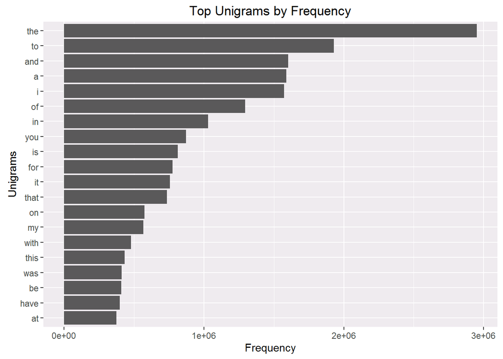

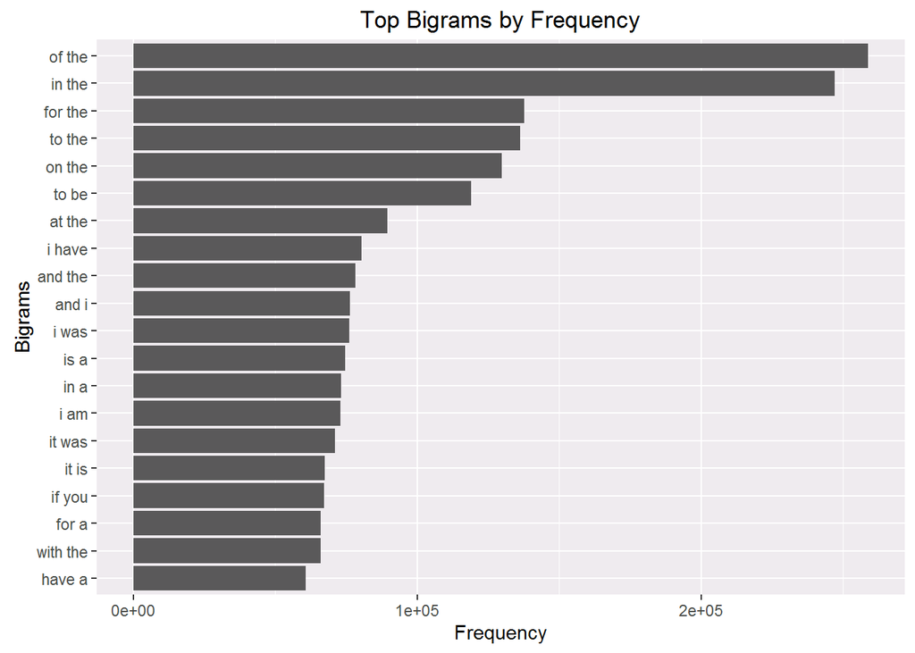

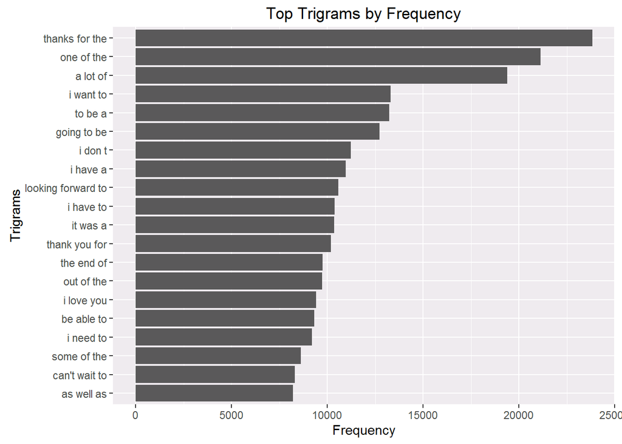

```r
g <- ggplot(head(df_unigram.all, 20),
            aes(x=reorder(word, frequency),y=frequency)) +
  geom_bar(stat = "identity") + coord_flip() +
  xlab("Unigrams") + ylab("Frequency") +
  labs(title = "Top Unigrams by Frequency")
print(g)
```

## Wordcloud

Finally, create Wordclouds of unigrams, bigrams and trigrams.

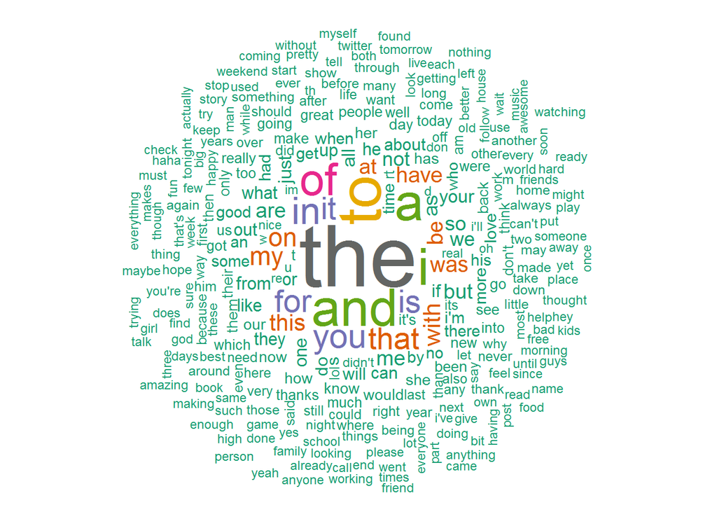

```r
par(mar=rep(0, 4))
pal <- brewer.pal(8, "Dark2")
# scale and number of words are arbitrarily chosen for filling up the space
wordcloud(df_unigram.all$word, df_unigram.all$frequency, scale=c(5, 0.7),
          min.freq=100, max.words=300, random.color=FALSE, colors=pal,
          rot.per = 0.25, random.order=FALSE)
```

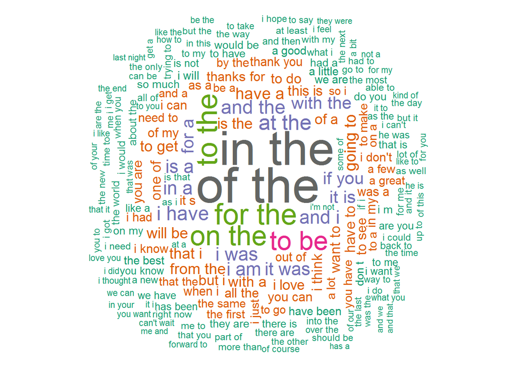

```r
wordcloud(df_bigram.all$word, df_bigram.all$frequency, scale=c(4, 0.5),
          min.freq=100, max.words=200, random.color=FALSE, colors=pal,
          rot.per = 0.25, random.order=FALSE)
```

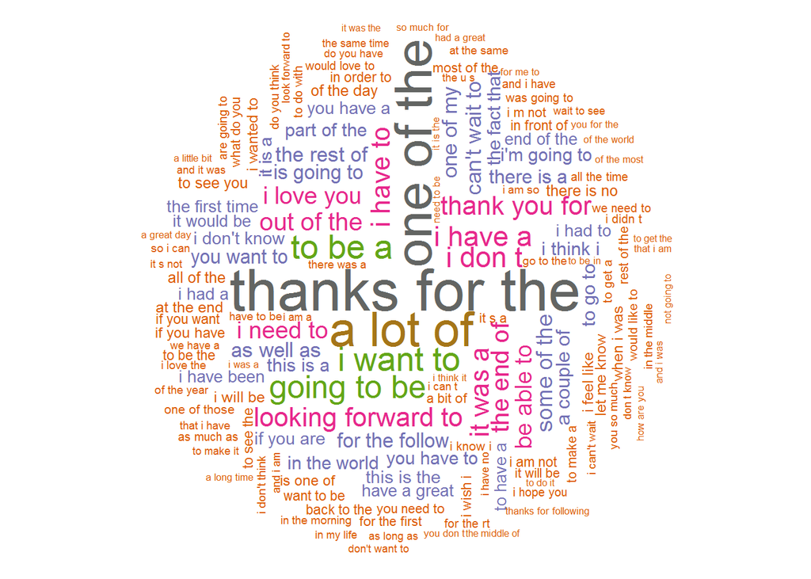

```r
wordcloud(df_trigram.all$word, df_trigram.all$frequency, scale=c(3, 0.1),
          min.freq=100, max.words=150, random.color=FALSE, colors=pal,
          rot.per = 0.25, random.order=FALSE)
```

# Algorithm and App Planning

## Goal

The goal of the algorithm is to be **given an m-gram and predict the next 5 possible n-grams with descending probability of apperance**, where m + n <= 5. Therefore, probability distribution of upto 5-gram will be needed for the full prediction algorithm.

## Workflow

The prediction will be based on **conditional probability**. The workflow will be as following: 1. For every known m-gram, calculate and rank conditional probabilities of the appearance of the next n-grams. 2. Keep only the top 5 for each m-gram. 3. When a certain m-gram is input by user, the top frequently used m-gram is output, followed by the next 4 frequently used m-grams.

## Memory vs. Time

For prediction speed, **array or dictionary** is the most preferred data structure to be able to access predicted outcome with a time complexity of O(1). However, this would yield a huge memory requirement to store all n-grams and prediction. Consider the following during development to balance memory and time cost of the algorithm: 1. Use a **Markov-chain** type of data structure to link given m-grams and their predictions; 2. Consider less frequently used n-grams (e.g. occurrance with unconditioinal probability of less than 0.1%) as invalid data for training the algorithm and drop them from the frequency distribution; 3. Delete unused intermediate variables once the algorithm is trained to save memory.

## Other Potential Improvements

1. *Unknown Input*: if an m-gram input is never seen, consider to use unconditional probability of appearance and/or only use a subset of the input for predicting the next n-gram.
2. *More Data*: Consider to use more text sources available in the public domain such as publications, websites and etc. to train the prediction algorithm.
3. *Source Optimization*: If the source of the input is specified (e.g. news, blogs or twitter), use an algorithm trained with the corresponded database to improve accuracy of the prediction.